# Html_Spotify_Podcast

## Load data

```python
import pandas as pd
import numpy as np

# Load the dataframes from csv files
podcasts_df = pd.read_csv("https://storage.googleapis.com/datalynn-datasets/interview-challenge/entertainment-and-media/Spotify_Podcast/podcasts.csv")
user_behavior_df = pd.read_csv("https://storage.googleapis.com/datalynn-datasets/interview-challenge/entertainment-and-media/Spotify_Podcast/user_behavior.csv")
```

### Q1

**Original Question**:

We want to understand the listening patterns across different genres and how user subscriptions to podcasts influence those patterns. Write a SQL query that groups the podcasts by genre, aggregates the average listening time, and filters only those genres where the subscription rate is above 0.5 .

### Solution:

**Problem-Solving Ideas and Tips:**

1. **Grouping by Genre:** We need to group the data by the genre to analyze the patterns across different genres.
2. **Calculating Average Listening Time:** The average listening time for each genre will provide insights into user engagement with different genres.
3. **Calculating Subscription Rate:** Subscription rate can be calculated as the ratio of the sum of subscriptions (1/0 values) to the total number of records for that genre.
4. **Filtering by Subscription Rate:** Applying a filter to include only the genres where the subscription rate is above a certain threshold will allow us to focus on the genres that have a higher engagement rate.

**SQL Query:**

Here's the SQL query to achieve the above logic. The threshold for the subscription rate can be adjusted based on the requirement.

```python
import sqlite3

# Create a new SQLite3 database in memory
conn = sqlite3.connect(":memory:")

# Convert Pandas DataFrames to SQL tables
podcasts_df.to_sql('Podcasts_Data_Table', conn, index=False)
user_behavior_df.to_sql('User_Behavior_Data_Table', conn, index=False)

# Define the SQL query
sql_query = """
SELECT
    genre,
    AVG(listen_time) AS avg_listen_time
FROM
    User_Behavior_Data_Table
GROUP BY
    genre
HAVING
    SUM(subscribed) * 1.0 / COUNT(subscribed) > 0.5;
"""

# Execute the query and fetch the results
cursor = conn.cursor()
cursor.execute(sql_query)
result = cursor.fetchall()

# Print the result
for row in result:
    print(row)

# Close the connection
conn.close()
```

```
('Arts', 47.10899182561308)
('Comedy', 43.43589743589744)
('Education', 46.43341404358353)
('Music', 41.705882352941174)
```

**Explanation:**

- The query groups the data by the `genre` column.
- The average listening time for each genre is calculated using the `AVG` function applied to the `listen_time` column.
- The subscription rate for each genre is calculated using the `SUM` and `COUNT` functions applied to the `subscribed` column.
- The `HAVING` clause filters the genres where the subscription rate is greater than a specified threshold (in this case, 0.5).

This query will provide insights into the genres that have higher engagement and subscription rates, which can be further used to optimize the discovery and engagement strategies for podcast listeners.

### Q2

**Original Question**:

You are tasked with analyzing user ratings and the impact of the launch date of podcasts. Determine how the rating of a podcast correlates with its launch date and duration, and identify the genre that is most affected by these factors.

### Solution

**Problem Solving Ideas and Tips:**

1. **Merge the DataFrames**: First, we need to merge the two DataFrames `podcasts_df` and `user_behavior_df` based on the common column `podcast_id`. This will allow us to analyze user ratings in conjunction with other podcast attributes.
2. **Correlation Analysis**: We can calculate the correlation between the rating and both the launch date and duration using a numerical measure like Pearson's correlation coefficient. The correlation will provide insights into how closely the rating is related to these attributes.
3. **Genre Analysis**: To identify the genre most affected by launch date and duration, we need to group the data by genre and analyze the correlation within each group.
4. **Visualizations**: Visualizations like scatter plots and heatmaps can be useful in interpreting the correlation.

**Python Code Solution:**

First, let's merge the two DataFrames and calculate the correlation between the rating and both the launch date and duration.

```python
import matplotlib.pyplot as plt
import seaborn as sns

# Merge DataFrames
merged_df = pd.merge(user_behavior_df, podcasts_df[['podcast_id', 'launch_date', 'duration']], on='podcast_id', suffixes=('', '_podcast'))

# Convert the 'launch_date' column to datetime format if it's not already
merged_df['launch_date'] = pd.to_datetime(merged_df['launch_date'])

# Convert launch_date to a numerical feature by extracting the year
merged_df['launch_year'] = merged_df['launch_date'].dt.year

# Calculate correlations
correlation_with_launch_date = merged_df['rating'].corr(merged_df['launch_year'])
correlation_with_duration = merged_df['rating'].corr(merged_df['duration_podcast'])

print("Correlation with Launch Date:", correlation_with_launch_date)
print("Correlation with Duration:", correlation_with_duration)
```

```
Correlation with Launch Date: -0.573482235690238
Correlation with Duration: -0.009856488818017655
```

Next, let's identify the genre most affected by these factors and visualize the data.

```
Genre most affected by Launch Date: Technology
Genre most affected by Duration: Music
```

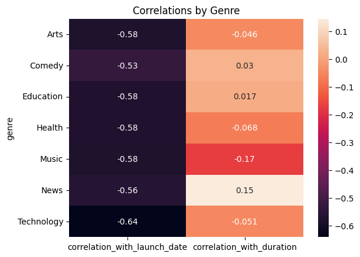

```python
# Group by genre and calculate correlations within each group
genre_correlations = merged_df.groupby('genre').apply(lambda group: pd.Series({
    'correlation_with_launch_date': group['rating'].corr(group['launch_date'].dt.year),
    'correlation_with_duration': group['rating'].corr(group['duration_podcast'])
}))

# Find the genre most affected
most_affected_genre = genre_correlations.abs().idxmax()

print("Genre most affected by Launch Date:", most_affected_genre['correlation_with_launch_date'])
print("Genre most affected by Duration:", most_affected_genre['correlation_with_duration'])

# Heatmap for genre correlations
sns.heatmap(genre_correlations, annot=True)
plt.title('Correlations by Genre')
plt.show()
```

### Q3

**Original Question**:

Spotify is planning to launch a new recommendation engine for podcasts. By considering a dataset with user ratings, listening time, and subscription status, build a regression model to predict a user's rating for a podcast. Identify the key features contributing to the predictions and provide insights on how to personalize podcast recommendations.

### Solution

#### Problem Solving Ideas and Tips:

1. **Data Exploration**: Start by exploring the given data, looking for correlations between variables, distribution of the target variable (ratings), and any missing values.
2. **Feature Selection**: Since the goal is to predict user ratings for podcasts, relevant features might include `listen_time`, `subscribed`, `genre`, `duration`, and any other factors that could influence user behavior.
3. **Data Preprocessing**: It might be necessary to convert categorical features like `genre` into numerical representations using techniques like one-hot encoding. Standardizing the numerical features could also be beneficial.
4. **Model Building**: A regression model can be used to predict the user's rating. Different regression techniques can be applied like linear regression, ridge regression, or random forest regressor to find the best model.
5. **Model Interpretation**: Look at the coefficients/feature importances of the chosen model to identify the key features contributing to the predictions.
6. **Insights and Recommendations**: Based on the model's key features, provide insights to help Spotify personalize podcast recommendations.

#### Solution:

Below, we go through the steps of building a regression model.

First, we'll import the necessary libraries and preprocess the data.

##### Preprocessing:

```python
from sklearn.preprocessing import StandardScaler, OneHotEncoder
from sklearn.compose import ColumnTransformer
from sklearn.pipeline import Pipeline
from sklearn.model_selection import train_test_split
from sklearn.linear_model import LinearRegression
from sklearn.metrics import mean_squared_error
from math import sqrt

# Separating features and target variable
X = user_behavior_df[['genre', 'duration', 'listen_time', 'subscribed']]
y = user_behavior_df['rating']

# Splitting data into training and test sets
X_train, X_test, y_train, y_test = train_test_split(X, y, test_size=0.2, random_state=42)

# Defining preprocessor for the numerical and categorical features
preprocessor = ColumnTransformer(
    transformers=[
        ('num', StandardScaler(), ['duration', 'listen_time']),
        ('cat', OneHotEncoder(), ['genre'])
    ])

# Including the preprocessor in a pipeline with the Linear Regression model
pipeline = Pipeline(steps=[
    ('preprocessor', preprocessor),
    ('regressor', LinearRegression())
])

# Fitting the model
pipeline.fit(X_train, y_train)

# Making predictions
y_pred = pipeline.predict(X_test)

# Calculating the RMSE
rmse = sqrt(mean_squared_error(y_test, y_pred))
print('Root Mean Squared Error:', rmse)
```

```
Root Mean Squared Error: 1.9972230539297848
```

##### Identifying Key Features:

To understand the importance of different features, you can look at the coefficients of the linear regression model.

```python
feature_names = list(preprocessor.named_transformers_['num'].get_feature_names_out(['duration', 'listen_time'])) \
                + list(preprocessor.named_transformers_['cat'].get_feature_names_out())

# Coefficients
coefs = pipeline.named_steps['regressor'].coef_

# Displaying the importance
for coef, name in zip(coefs, feature_names):
    print(name, coef)
```

```
duration 0.008055003771853775
listen_time -0.033999557303116545
genre_Arts 0.06325921544057928
genre_Comedy -0.03029757189178148
genre_Education -0.03869877059244513
genre_Health 0.06230793615991627
genre_Music 0.0005630323853337746
genre_News -0.09789945667478049
genre_Technology 0.04076561517317783
```

##### Insights:

Based on the coefficients, you can provide insights into which features are most influential in predicting user ratings. For instance, if the `listen_time` coefficient is positive, it suggests that more time spent listening to a podcast correlates with higher ratings. Similarly, if a particular genre has a high coefficient, it indicates that this genre generally receives higher ratings.